# Practical_Machine_learning

Rashmi Priya

February 18, 2017

### 1.Environment Preparation

Let us load all the R libraries that will be needed for our analysis.

```r
library(knitr)
library(caret)
```

```r
library(rpart)
library(rpart.plot)
library(rattle)
library(randomForest)
library(corrplot)
```

### 2. Data Loading and Cleaning

Separating the training and the testing data

```r
training <- read.csv("pml-training.csv")
testing <- read.csv("pml-testing.csv")
```

Partitioning training data again into training and testing data sets so that we can perform our analysis.

```r
inTrain  <- createDataPartition(training$classe, p=0.7, list=FALSE)
trainingset <- training[inTrain, ]
testingset  <- training[-inTrain, ]
dim(trainingset)
```

```
## [1] 13737   160
```

```r
dim(testingset)
```

```
## [1] 5885  160
```

We can see that the data has huge amount of NA and we would like to remove them.

```r
NZV <- nearZeroVar(trainingset)
trainingset <- trainingset[, -NZV]
testingset  <- testingset[, -NZV]
dim(trainingset)
```

```
## [1] 13737   105
```

```r
dim(testingset)
```

```
## [1] 5885  105
```

```r
removeNA <- sapply(trainingset, function(x) mean(is.na(x))) > 0.95
trainingset <- trainingset[, removeNA==FALSE]
testingset <- testingset[, removeNA==FALSE]
dim(trainingset)
```

```
## [1] 13737    59
```

```r
dim(testingset)
```

```
## [1] 5885   59
```

Data looks clean. Though we can still do further cleaning by removing variables that has 90% or 95% NA. Lets choose 95% for this model.

```r
removeNA <- sapply(trainingset, function(x) mean(is.na(x))) > 0.95
trainingset <- trainingset[, removeNA==FALSE]
testingset <- testingset[, removeNA==FALSE]
dim(trainingset)
```

```
## [1] 13737    59
```

```r
dim(testingset)
```

```
## [1] 5885   59
```

Let us remove identification only variables (columns 1 to 5)

```r
trainingset <- trainingset[, -(1:5)]
testingset  <- testingset[, -(1:5)]
dim(trainingset)
```

```
## [1] 13737    54
```

```r
dim(testingset)
```

```
## [1] 5885   54
```

### 3. Correlation Analysis

A correlation among variables is analysed before proceeding to the modeling procedures.

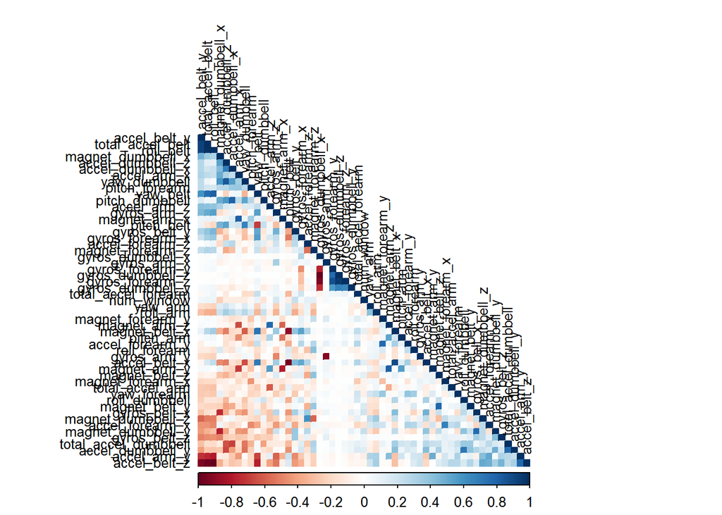

```r
corMatrix <- cor(trainingset[, -54])
corrplot(corMatrix, order = "FPC", method = "color", type = "lower",
         tl.cex = 0.8, tl.col = rgb(0, 0, 0))
```

### 4. Prediction Model Building

We can use random Forests, Decision Tree and Generalized Boosted Model to model our datasets. A Confusion Matrix is plotted at the end of each analysis to better visualize the accuracy of the models.

#### a) Method: Random Forest

```r
set.seed(12345)
controlRF <- trainControl(method="cv", number=3, verboseIter=FALSE)
modFitRandForest <- train(classe ~ ., data=trainingset, method="rf",
                          trControl=controlRF)
modFitRandForest$finalModel
```

```
##
## Call:
##  randomForest(x = x, y = y, mtry = param$mtry)
##                Type of random forest: classification
##                      Number of trees: 500
## No. of variables tried at each split: 27
##
##         OOB estimate of  error rate: 0.26%
## Confusion matrix:
##      A    B    C    D    E  class.error
## A 3904    1    0    0    1 0.0005120328
## B    6 2649    3    0    0 0.0033860045
## C    0    6 2390    0    0 0.0025041736
## D    0    0   13 2238    1 0.0062166963
## E    0    0    0    5 2520 0.0019801980
```

```r
predictRandForest <- predict(modFitRandForest, newdata=testingset)
confMatRandForest <- confusionMatrix(predictRandForest, testingset$classe)
confMatRandForest
```

```
## Confusion Matrix and Statistics
##
##           Reference
## Prediction    A    B    C    D    E
##          A 1674    2    0    0    0
##          B    0 1136    4    0    0
##          C    0    1 1022    2    0
##          D    0    0    0  961    0
##          E    0    0    0    1 1082
##
## Overall Statistics
##
##                Accuracy : 0.9983
##                  95% CI : (0.9969, 0.9992)
##     No Information Rate : 0.2845
##     P-Value [Acc > NIR] : < 2.2e-16
##
##                   Kappa : 0.9979
##  Mcnemar's Test P-Value : NA
##
## Statistics by Class:
##
##                      Class: A Class: B Class: C Class: D Class: E
## Sensitivity            1.0000   0.9974   0.9961   0.9969   1.0000
## Specificity            0.9995   0.9992   0.9994   1.0000   0.9998
## Pos Pred Value         0.9988   0.9965   0.9971   1.0000   0.9991
## Neg Pred Value         1.0000   0.9994   0.9992   0.9994   1.0000
## Prevalence             0.2845   0.1935   0.1743   0.1638   0.1839
## Detection Rate         0.2845   0.1930   0.1737   0.1633   0.1839
## Detection Prevalence   0.2848   0.1937   0.1742   0.1633   0.1840
## Balanced Accuracy      0.9998   0.9983   0.9977   0.9984   0.9999
```

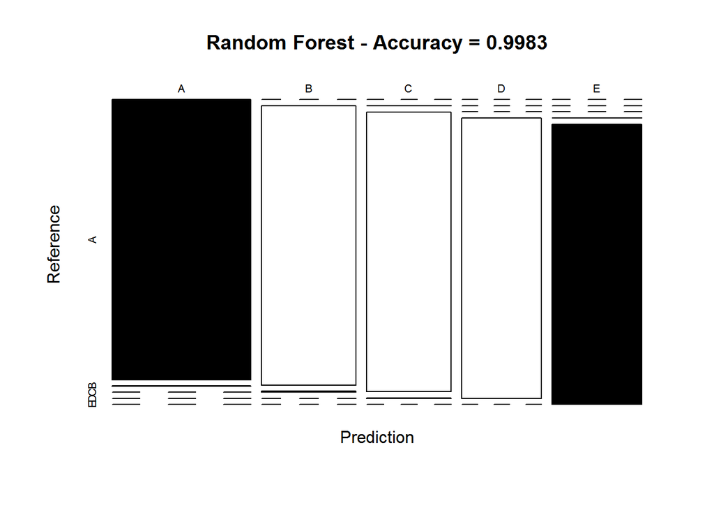

```r
plot(confMatRandForest$table, col = confMatRandForest$byClass,
     main = paste("Random Forest - Accuracy =",
                  round(confMatRandForest$overall['Accuracy'], 4)))
```

#### b) Method: Decision Trees

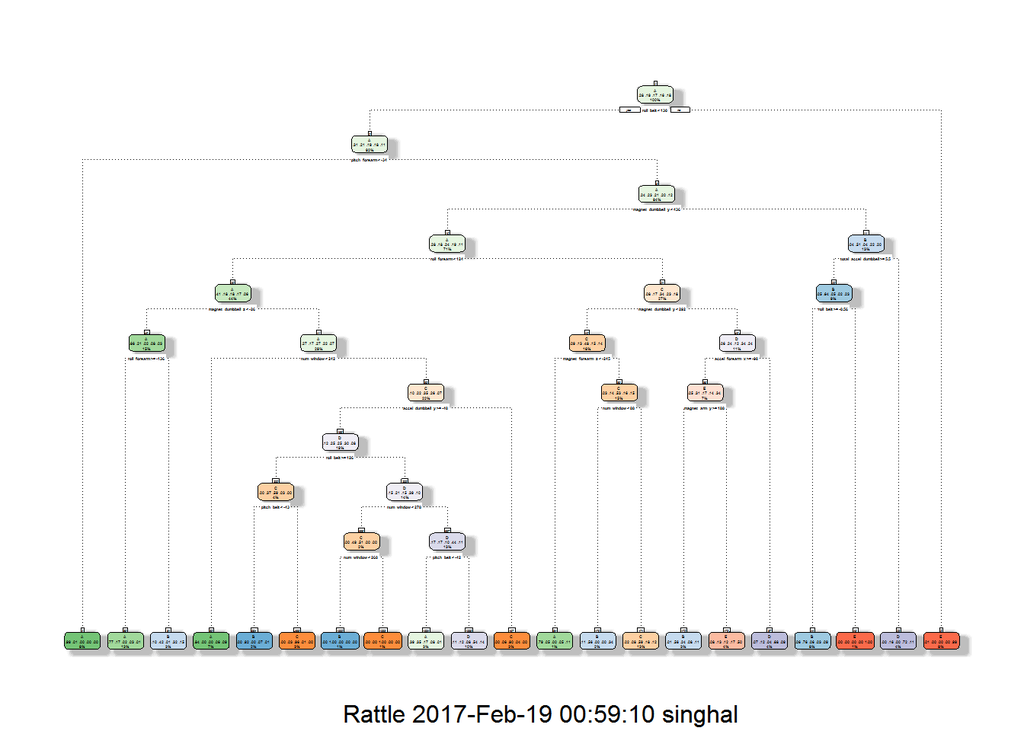

```r
modFitDecTree <- rpart(classe ~ ., data=trainingset, method="class")
fancyRpartPlot(modFitDecTree)
```

```r
predictDecTree <- predict(modFitDecTree, newdata=testingset, type="class")
confMatDecTree <- confusionMatrix(predictDecTree, testingset$classe)
confMatDecTree
```

```
## Confusion Matrix and Statistics
##
##           Reference
## Prediction    A    B    C    D    E
##          A 1498  191   43   54   57
##          B   56  692   75   91  119
##          C   17   68  830  131   82
##          D   84  145   56  648  135
##          E   19   43   22   40  689
##
## Overall Statistics
##
##                Accuracy : 0.7404
##                  95% CI : (0.729, 0.7515)
##     No Information Rate : 0.2845
##     P-Value [Acc > NIR] : < 2.2e-16
##
##                   Kappa : 0.6707
##  Mcnemar's Test P-Value : < 2.2e-16
##
## Statistics by Class:
##
##                      Class: A Class: B Class: C Class: D Class: E
## Sensitivity            0.8949   0.6076   0.8090   0.6722   0.6368
## Specificity            0.9181   0.9282   0.9387   0.9147   0.9742
## Pos Pred Value         0.8128   0.6699   0.7358   0.6067   0.8475
## Neg Pred Value         0.9565   0.9079   0.9588   0.9344   0.9225
## Prevalence             0.2845   0.1935   0.1743   0.1638   0.1839
## Detection Rate         0.2545   0.1176   0.1410   0.1101   0.1171
## Detection Prevalence   0.3132   0.1755   0.1917   0.1815   0.1381
## Balanced Accuracy      0.9065   0.7679   0.8738   0.7934   0.8055
```

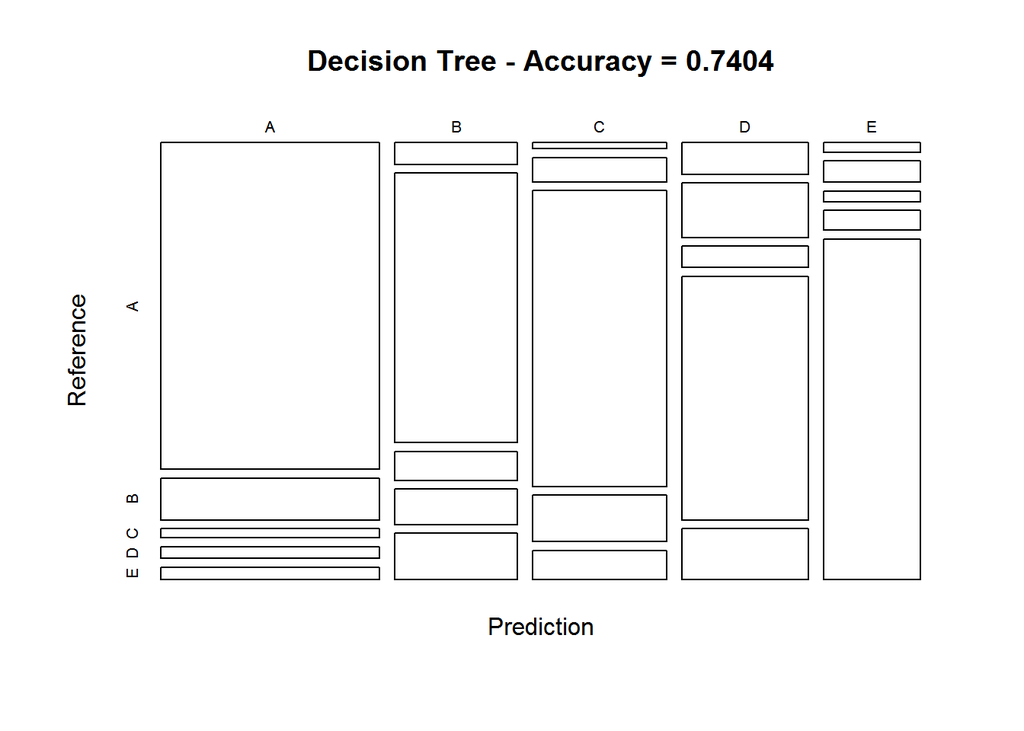

```r
plot(confMatDecTree$table, col = confMatDecTree$byClass,
     main = paste("Decision Tree - Accuracy =",
                  round(confMatDecTree$overall['Accuracy'], 4)))
```

#### c) Method: Generalized Boosted Model

```r
set.seed(12345)
controlGBM <- trainControl(method = "repeatedcv", number = 5, repeats = 1)
modFitGBM  <- train(classe ~ ., data=trainingset, method = "gbm",
                    trControl = controlGBM, verbose = FALSE)
modFitGBM$finalModel
```

```
## A gradient boosted model with multinomial loss function.
## 150 iterations were performed.
## There were 53 predictors of which 41 had non-zero influence.
```

```r
predictGBM <- predict(modFitGBM, newdata=testingset)
confMatGBM <- confusionMatrix(predictGBM, testingset$classe)
confMatGBM
```

```
## Confusion Matrix and Statistics
##
##           Reference
## Prediction    A    B    C    D    E
##          A 1668    8    0    3    0
##          B    4 1117   11    0    2
##          C    0   14 1010    4    1
##          D    2    0    4  955    4
##          E    0    0    1    2 1075
##
## Overall Statistics
##
##                Accuracy : 0.9898
##                  95% CI : (0.9869, 0.9922)
##     No Information Rate : 0.2845
##     P-Value [Acc > NIR] : < 2.2e-16
##
##                   Kappa : 0.9871
##  Mcnemar's Test P-Value : NA
##
## Statistics by Class:
##
##                      Class: A Class: B Class: C Class: D Class: E
## Sensitivity            0.9964   0.9807   0.9844   0.9907   0.9935
## Specificity            0.9974   0.9964   0.9961   0.9980   0.9994
## Pos Pred Value         0.9934   0.9850   0.9815   0.9896   0.9972
## Neg Pred Value         0.9986   0.9954   0.9967   0.9982   0.9985
## Prevalence             0.2845   0.1935   0.1743   0.1638   0.1839
## Detection Rate         0.2834   0.1898   0.1716   0.1623   0.1827
## Detection Prevalence   0.2853   0.1927   0.1749   0.1640   0.1832
## Balanced Accuracy      0.9969   0.9886   0.9902   0.9943   0.9965
```

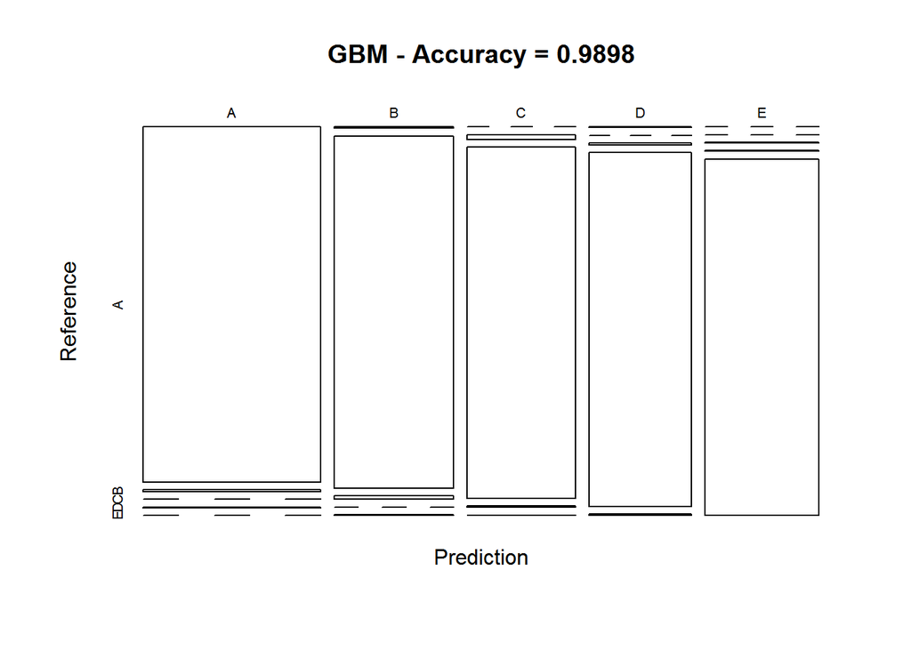

```r
plot(confMatGBM$table, col = confMatGBM$byClass,
     main = paste("GBM - Accuracy =", round(confMatGBM$overall['Accuracy'], 4)))
```

#### 5. Applying the Selected Model to the Test Data

In that case, the Random Forest model will be applied to predict the testing dataset.

```r
predictTEST <- predict(modFitRandForest, newdata=testing)
predictTEST
```

```
##  [1] B A B A A E D B A A B C B A E E A B B B
## Levels: A B C D E
```